# Elementos de estadística para análisis de expresión diferencial

Octubre 24, 2016

## Temas

- Modelos lineales
- P-value
- Problema de multiplicidad de pruebas
- Fuentes de variación en experimentos de RNA-seq

## Temas

- **Modelos lineales**
- P-value
- Problema de multiplicidad de pruebas
- Fuentes de variación en experimentos de RNA-seq

## ¿Qué es un regresión lineal?

- Una regresión lineal modela la respuesta de una variable \(Y\) como una combinación lineal de variables predictoras \(X\).

\(Y = \beta_0 + \beta_1 X + \varepsilon\)

donde

- \(X\): es un vector de predictores o variables independientes \(X = \{x_{1}, x_{2},...,x_{n}\}\)
- \(Y\): es la variable a predecir o la variable dependientes \(Y = \{y_{1}, y_{2},...,y_{n}\}\)
- \(\beta_p\): son los coeficientes de la regresión, los parámetros a estimar
- \(\varepsilon\): es el error del modelo

## Ejemplo de una regresión lineal I

Por vecindario,

- **lstat** es el porcentage de casas con nivel socio económico bajo
- **medv** es el valor medio de una casa
- **age** es la edad media de las casas

```r
library(MASS)
data("Boston")
head( Boston[,c("lstat", "medv", "age")])
```

```
##   lstat medv  age
## 1  4.98 24.0 65.2
## 2  9.14 21.6 78.9
## 3  4.03 34.7 61.1
## 4  2.94 33.4 45.8
## 5  5.33 36.2 54.2
## 6  5.21 28.7 58.7
```

## Ejemplo de una regresión lineal II

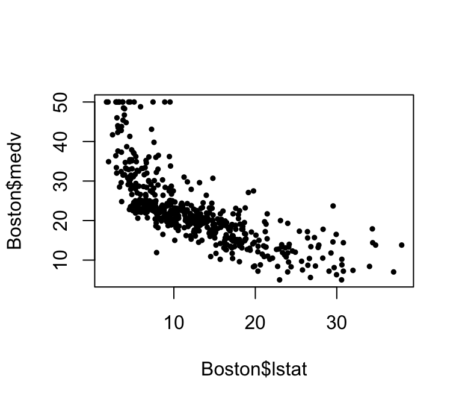

```r
plot(Boston$lstat, Boston$medv, pch=19, cex=.5)
```

## Ejemplo de una regresión lineal III

\(medv \approx \beta_0 + \beta_1 lstat\)

```r
modelo <- lm( medv ~ lstat, Boston )
modelo
```

```
##
## Call:
## lm(formula = medv ~ lstat, data = Boston)
##
## Coefficients:
## (Intercept)        lstat
##       34.55        -0.95
```

## Ejemplo de una regresión lineal IV

¿Cuál es el precio medio que el modelo predice si el % de casas con nivel socioeconómico bajo es del 15%?

```r
coefs <- coefficients( modelo )
coefs["(Intercept)"] + coefs["lstat"] * 15
```

```
## (Intercept)
##     20.3031
```

## Ejemplo de una regresión lineal V

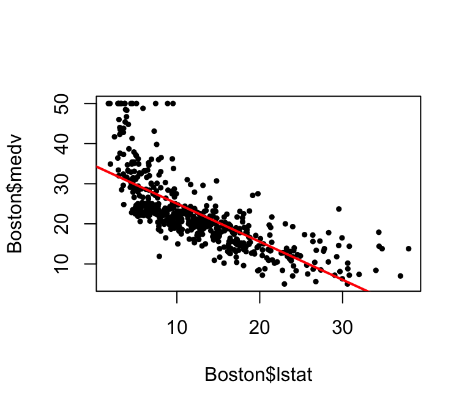

```r
plot(Boston$lstat, Boston$medv, pch=19, cex=.5)
abline(modelo, lwd=2, col="red")
```

## Regresión lineal múltiple

\(Y = \beta_0 + \beta_1 X_1 + \beta_2 X_2 + \varepsilon\)

\(medv \approx \beta_0 + \beta_1 lstat + \beta_2 age\)

```r
modelo2 <- lm( medv ~ lstat + age, Boston )
modelo2
```

```
##
## Call:
## lm(formula = medv ~ lstat + age, data = Boston)
##
## Coefficients:
## (Intercept)        lstat          age
##    33.22276     -1.03207      0.03454
```

## Ejercicio I

¿Cuál es el precio medio estimado por el modelo si el porcentage de casas con nivel socioeconómico bajo es del 10% y si la edad media de las casas es de 20 años?

## Regresiones con variables cualitativas I

```r
library(ISLR)
data( Default )
head( Default )
```

```
##   default student   balance    income
## 1      No      No  729.5265 44361.625
## 2      No     Yes  817.1804 12106.135
## 3      No      No 1073.5492 31767.139
## 4      No      No  529.2506 35704.494
## 5      No      No  785.6559 38463.496
## 6      No     Yes  919.5885  7491.559
```

## Regresiones con variables cualitativas II

"dummy variables" para codificar los factores cualitativos

\(Y \approx \beta_0 + \beta_1 X\)

## Regresiones con variables cualitativas II

```r
lm( income ~ student, Default )
```

```
##
## Call:
## lm(formula = income ~ student, data = Default)
##
## Coefficients:
## (Intercept)   studentYes
##       40012       -22062
```

## Regresiones con coefficientes de interacción

\(Y \approx \beta_0 + \beta_1 X_1 + \beta_2 X_2 + \beta_3 X_1 X_2\)

```r
modelo3 <- lm( balance ~ income * student, Default )
modelo3
```

```
##
## Call:
## lm(formula = balance ~ income * student, data = Default)
##
## Coefficients:
##       (Intercept)             income         studentYes
##         7.605e+02          2.819e-04          2.625e+02
## income:studentYes
##        -2.243e-03
```

## Conclusion I

- Los modelos lineales son funciones que sirven para describir la relación de una variable dependiente con respecto a otra variable independiente.
- ¿Porqué esto es importante para expresión diferencial?

## Temas

- Modelos lineales
- **P-value**
- Problema de multiplicidad de pruebas
- Fuentes de variación en experimentos de RNA-seq

## ¿Qué es un valor p?

Es la probabilidad de observar al azar un valor tan extremo como el observado.

## Comparando modelos y calculando p-values I

\(Y \approx \beta_0 + \beta_1 X_1\)

\(Y:\) salario

\(X:\) { \(x_{i} = 1\) si es estudiante, \(x_{i} = 0\) si no es estudiante }

\(H_{0}: \beta_1 = 0\)

## Comparando modelos y calculando p-values II

\(RSS = \sum^{n}_{i=1} ( y_{i} - \hat{y_{i}} )^{2}\)

\(F = \frac{ (RSS_{0} - RSS_{1} ) / q}{RSS_{1} / (n-p-1)}\)

\(q:\) número de parametros flexibles (extra)

\(p:\) número de parametros fijos

\(n:\) número de observaciones

\(RSS_{0}:\) RSS del modelo nulo

\(RSS_{1}:\) RSS del modelo completo

## Comparando modelos y calculando p-values III

```r
anova( lm( income ~ student, Default ) )
```

```
## Analysis of Variance Table
##
## Response: income
##             Df     Sum Sq    Mean Sq F value    Pr(>F)
## student      1 1.0111e+12 1.0111e+12   13172 < 2.2e-16 ***
## Residuals 9998 7.6743e+11 7.6758e+07
## ---
## Signif. codes:  0 '***' 0.001 '**' 0.01 '*' 0.05 '.' 0.1 ' ' 1
```

## Ejercicio 2

Decir qué \(\beta\)'s son estadísticamente significativas en el modelo

\(Y \approx \beta_0 + \beta_1 X_1 + \beta_2 X_2 + \beta_3 X_1 X_2\)

donde,

\(X_1:\) income \(X_2:\) student

## Temas

- Modelos lineales
- P-value
- **Problema de multiplicidad de pruebas**
- Fuentes de variación en experimentos de RNA-seq

## Problema de multiplicidad de pruebas I

Definimos una función que hace un test para ver si hay diferencias entre dos distrubuciones.

```r
getPval <- function(grupoA, grupoB){
    x <- c( grupoA, grupoB )
    y <- rep(c("A", "B"), each=50)
    anova( lm( x ~ y ) )["y","Pr(>F)"]
}

getPval( rnorm( n=50, mean=0 ), rnorm( n=50, mean=50 ))
```

```
## [1] 2.390459e-139
```

```r
getPval( rnorm( n=50, mean=0 ), rnorm( n=50, mean=0 ) )
```

```
## [1] 0.2172267
```

## Problema de multiplicidad de pruebas II

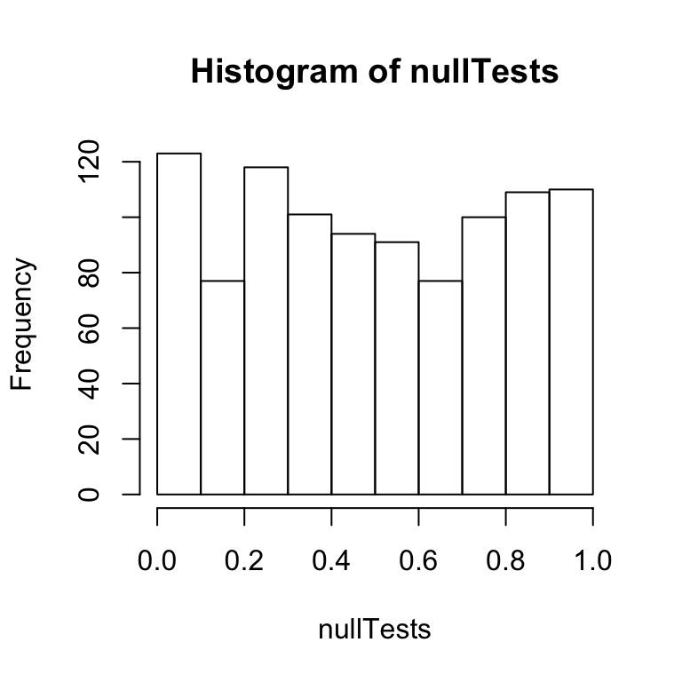

```r
nullTests <- replicate( 1000,
    getPval( rnorm(50, mean=0), rnorm(n=50, mean=0))
    )
hist( nullTests )
```

## Problema de multiplicidad de pruebas II

¿Cuántos valores \(p\) estarán debajo de 0.1 si hacemos 1000 pruebas nulas?

```r
table( nullTests < 0.1 )
```

```
##
## FALSE  TRUE
##   877   123
```

## Problema de multiplicidad de pruebas III

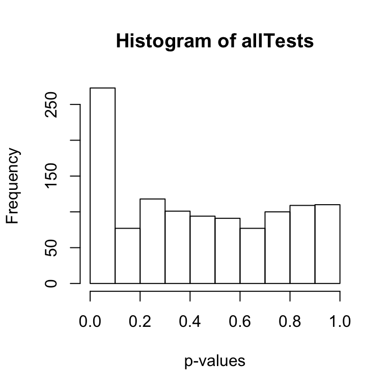

```r
altTests <- replicate( 150,
    getPval( rnorm(50, mean=0), rnorm(n=50, mean=50))
    )
allTests <- c(altTests, nullTests)
hist( allTests, xlab="p-values")
```

## Problema de multiplicidad de pruebas IV

¿Cómo corregir? (FWER y FDR)

```r
qvalues <- p.adjust( allTests, method="BH" )
table( allTests < 0.1 )
```

```
##
## FALSE  TRUE
##   877   273
```

```r
table( qvalues < 0.1 )
```

```
##
## FALSE  TRUE
##   985   165
```

## Problema de multiplicidad de pruebas V

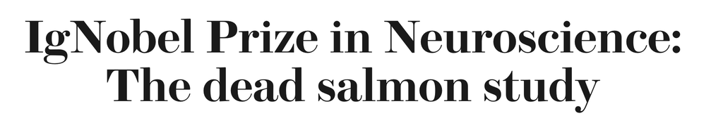

¿En expresión diferencial, hay problemas de multiplicidad de pruebas?

## Temas

- Modelos lineales
- P-value
- Problema de multiplicidad de pruebas
- **Fuentes de variación y diseño de experimentos de RNA-seq**

## Diseño de experimentos

**"To call in the statistician after the experiment is done may be no more than asking him to perform a postmortem examination: he may be able to say what the experiment died of."**  
*Sir Ronald Fisher, Indian Statistical Congress, Sankhya, around 1938*

## ¿Cómo hacer un diseño experimental defectuoso?

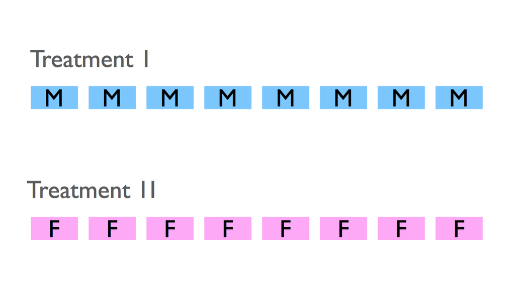

## ¿Cómo hacer un diseño experimental defectuoso?

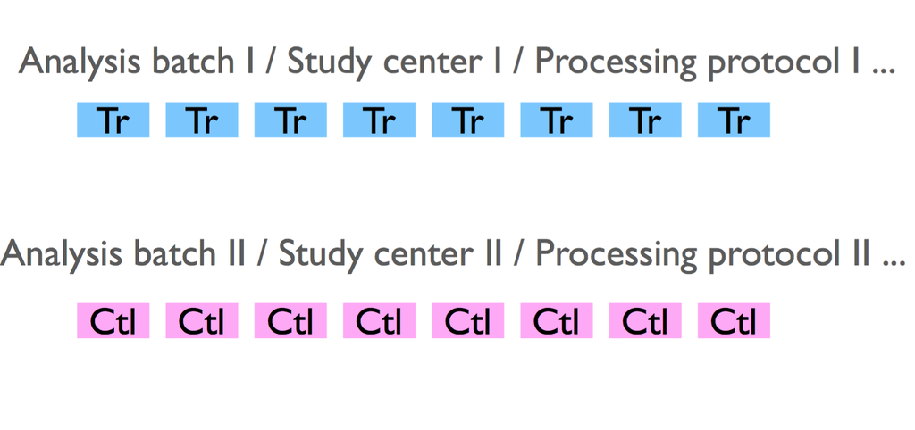

## Casos polémicos debido a diseños experimentales defectuosos

- Spielman et al., Nature Genetics 2007
  - 78% de los genes estan diferencialmente expresados entre poblaciones humanas.
  - Diseño confundido por la fecha de procesamiento de muestras.
- Lin et al., PNAS, 2014
  - Diferencias en expresión entre dos especies son mayores a las diferencias en expresión génica entre dos tejidos.
  - Diseño confundido por protocolos de extracción y sequenciación de RNA

## ¿Cómo tomar evitar que factores de confusión arruinen experimentos?

- Procesar todas las muestras idénticamente.
- Si no es posible: aleatorizar y anotar las muestras detalladamente. (Incluyendo flowcells)

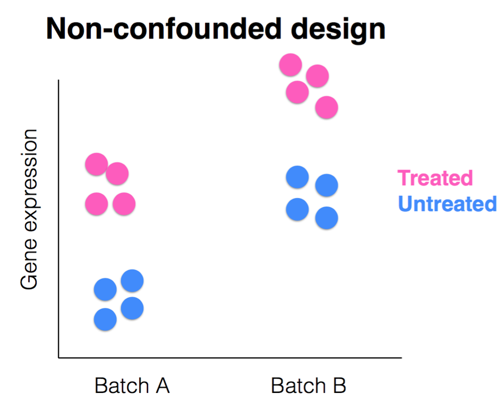

## Variación en cuentas de *RNA-seq*

* Variación = variación técnica + variación biológica

## Variación técnica en cuentas de *RNA-seq* (Poisson) I

Asuman que tienen un costal con pelotas, 90% son blancas y el 10% son rojas. A 50 personas (que no saben lo anterior) les dan la tarea de estimar el porcentage de pelotas blancas haciendo una muestra de *n* pelotas.

- ¿Cuál es el valor estimado de pelotas rojas si *n* = 20?

## Variación técnica en cuentas de *RNA-seq* (Poisson) II

```r
obtenerValorEsperado <- function( fracPelotasBlancas, n )
{
    valorEsperado <- n * fracPelotasBlancas
    valorEsperado
}
n <- 20
fracPelotasBlancas <- .1
valorEsperado <-
  obtenerValorEsperado( fracPelotasBlancas, n )
valorEsperado
```

```
## [1] 2
```

## Variación técnica en cuentas de *RNA-seq* (Poisson) III

```r
numPersonas <- 50
resSampleo <- rpois( numPersonas, valorEsperado )
resSampleo
```

```
##  [1] 4 3 1 2 5 5 0 0 1 1 3 3 0 3 1 2 1 0 1 3 2 0 2
## [24] 0 1 0 4 6 0 2 1 2 3 1 2 2 2 4 2 1 2 0 2 2 3 2
## [47] 2 3 1 2
```

## Variación técnica en cuentas de *RNA-seq* (Poisson) IV

**la media es igual a la varianza**

```r
valorEsperado
```

```
## [1] 2
```

```r
var( resSampleo )
```

```
## [1] 2.05102
```

## Variación técnica en cuentas de *RNA-seq* (Poisson) V

El error de aproximación es de:

```r
standarDev <- sqrt( valorEsperado )
standarDev / valorEsperado
```

```
## [1] 0.7071068
```

Que significa que los valores muestrados tienen una incertidumbre del 71%.

¿Qué sucede con el error de aproximación si el valor esperado incrementa? ¿Cómo podemos aumentar el valor esperado?

```r
valorEsperado <- n * fracPelotasBlancas
```

## Variación técnica en cuentas de *RNA-seq* (Poisson) VI

**El error de aproximación depende de la media**

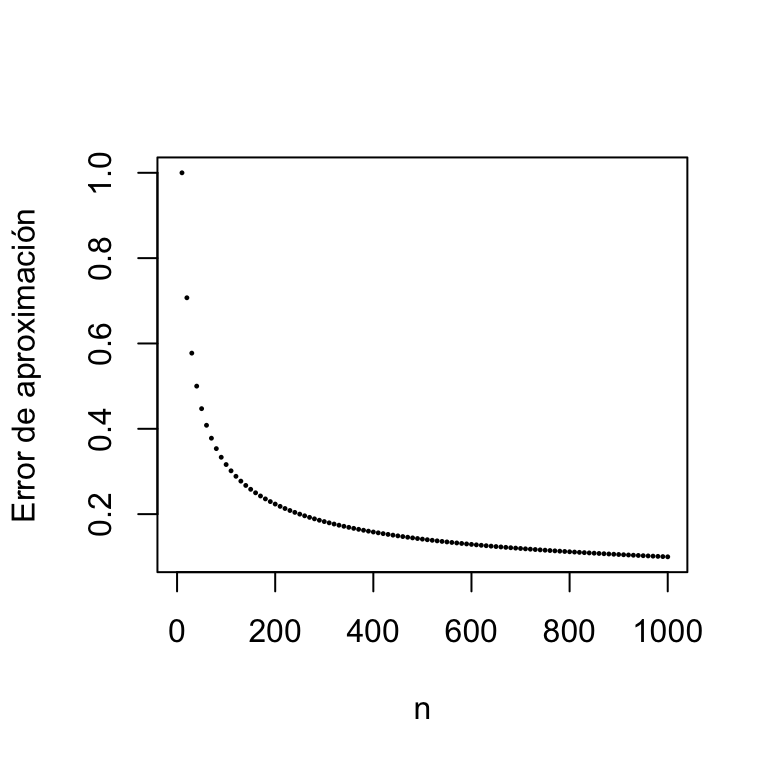

```r
n=seq(0, 1000, 10)
x <- obtenerValorEsperado( fracPelotasBlancas, n)
ea <- sqrt(x)/x
plot( n, ea, ylab="Error de aproximación", pch=19, cex=.2)
```

## Variación técnica en cuentas de *RNA-seq* (Poisson) V

**¿Cómo se traduce ésto a RNA-seq?**

- Sampleo = pasos de sequenciacion (rtPCR)
- n = cobertura
- Varianza técnica puede ser estimado de los datos (varianza = media)
- Entre más cobertura, menos varianza técnica

## Variación biológica en experimentos de RNA-seq

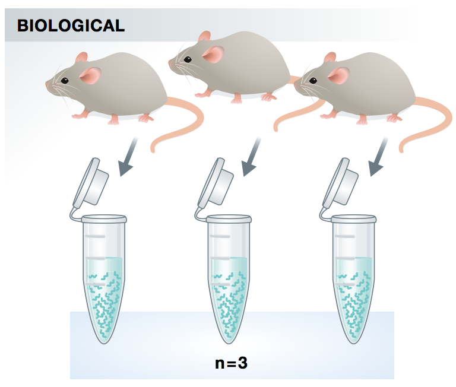

Klaus et al. The EMBO Journal. 2015

## Modelo de DESeq2

\(K_{ij} \sim \operatorname{NB}(\text{mean}=s_j\mu_{ij},\text{dispersion}=\alpha_i)\)

\(K_{ij}:\) cuentas del gen \(i\) en la muestra \(j\)

\(s_{j}:\) factor de normalización

\(\alpha_{i}:\) dispersión de las cuentas de un gen entre réplicas biológicas

## Fin

GRACIAS!